# Case Study on Bellabeat Utilizing R for Data Analysis and Visualization

Abdellah Gram

2023-12-14

## About a company

Bellabeat, a high-tech manufacturer of health-focused products for women, and meet different characters and team members.Bellabeat lunched multiple products which became available through a growing number of online retailers in addition to their own e-commerce channel on their website.Bellbeat’s marketing analytics team has benn asked to focus on a Bellabeat product and analyze smart device usage data in order to gain insight into how people are already using their smart devices. Then, using this information, the team must suggest a high-level recommendations for how these trends can inform Bellabeat marketing strategy.

As a data analyst and In order to answer the key business questions, I will follow the steps of the data analysis process: **ask**, **prepare**, **process**, **analyze**, **share**, and **act**.

## Ask

### Guiding questions

1. What are some trends in smart device usage?
2. How could these trends apply to Bellabeat customers?
3. How could these trends help influence Bellabeat marketing strategy?

### Business task

**Analyze** and **Identify** the trends in the usage of non-bellabeat smart devices offered to the costumes. These trends and insights will guide and be included in the Bellabeat apps and services in order to satisfy the customers and offer them what they need

## Prepare

● **[FitBit Fitness Tracker Data](https://www.kaggle.com/datasets/arashnic/fitbit)** (CC0: Public Domain, dataset made available through Mobius): This Kaggle data set contains personal fitness tracker from thirty fitbit users. Thirty eligible Fitbit users consented to the submission of personal tracker data, including minute-level output for physical activity, heart rate, and sleep monitoring. It includes information about daily activity, steps, and heart rate that can be used to explore users’ habits.

### Loading packages

```r
library(tidyverse)
```

```r
library(lubridate)
library(dplyr)
library(ggplot2)
library(tidyr)
```

### Importing datasets

```r
# Read CSV files
activity<- read.csv("archive/Fitabase_Data2016/dailyActivity_merged.csv")
daily_Calories<- read.csv("archive/Fitabase_Data2016/dailyCalories_merged.csv")
hourly_Calories<- read.csv("archive/Fitabase_Data2016/hourlyCalories_merged.csv")
daily_Steps <-read.csv("archive/Fitabase_Data2016/dailySteps_merged.csv")
hourly_Steps <- read.csv("archive/Fitabase_Data2016/hourlySteps_merged.csv")
daily_Sleep <-read.csv("archive/Fitabase_Data2016/sleepDay_merged.csv")
```

Now that we have six main datasets, we’re ready to analyze user performance. Our focus will be on key metrics like activity intensity, calories, steps, and sleep. These datasets form the basis for gaining valuable insights into user behavior and overall well-being.

### Exploring the datasets using the ‘head()’ function.

```r
head(daily_Calories)
```

```
##           Id ActivityDay Calories
## 1 1503960366   4/12/2016     1985
## 2 1503960366   4/13/2016     1797
## 3 1503960366   4/14/2016     1776
## 4 1503960366   4/15/2016     1745
## 5 1503960366   4/16/2016     1863
## 6 1503960366   4/17/2016     1728
```

Now, a problem arises as we encounter date formats that need to be reformatted from characters to dates for all dates and datasets

### Formatting

```r
activity$ActivityDate <-format(activity$ActivityDate , format="%m%d%y")
daily_Calories$ActivityDay <- as.Date(daily_Calories$ActivityDay, format = "%m/%d/%Y")
daily_Steps$ActivityDay <- as.Date(daily_Steps$ActivityDay, format = "%m/%d/%Y")
daily_Sleep$SleepDay <- as.POSIXct(daily_Sleep$SleepDay, format = "%m/%d/%Y %I:%M:%S %p")
```

```r
n_distinct(activity$Id)
```

```
## [1] 33
```

```r
n_distinct(daily_Calories$Id)
```

```
## [1] 33
```

```r
n_distinct(daily_Steps$Id)
```

```
## [1] 33
```

```r
n_distinct(daily_Sleep$Id)
```

```
## [1] 24
```

As shown above, we examined data from 33 users in the activity, calories, and steps datasets, and 24 users in the sleep dataset. However, it’s important to note that the sample size of 33 users may not be sufficient for drawing definitive data-based conclusions.

```r
# activity : Activity category per Distance
activity %>%
  select(ActivityDate ,TotalSteps ,LightActiveDistance , VeryActiveDistance , Calories) %>%
  summary()
```

```
##  ActivityDate         TotalSteps    LightActiveDistance VeryActiveDistance
##  Length:940         Min.   :    0   Min.   : 0.000      Min.   : 0.000
##  Class :character   1st Qu.: 3790   1st Qu.: 1.945      1st Qu.: 0.000
##  Mode  :character   Median : 7406   Median : 3.365      Median : 0.210
##                     Mean   : 7638   Mean   : 3.341      Mean   : 1.503
##                     3rd Qu.:10727   3rd Qu.: 4.782      3rd Qu.: 2.053
##                     Max.   :36019   Max.   :10.710      Max.   :21.920
##     Calories
##  Min.   :   0
##  1st Qu.:1828
##  Median :2134
##  Mean   :2304
##  3rd Qu.:2793
##  Max.   :4900
```

```r
# activity : Activity category per Minutes
activity %>%
  select(ActivityDate ,TotalSteps ,VeryActiveMinutes , FairlyActiveMinutes, LightlyActiveMinutes    ,SedentaryMinutes , Calories) %>%
  summary()
```

```
##  ActivityDate         TotalSteps    VeryActiveMinutes FairlyActiveMinutes
##  Length:940         Min.   :    0   Min.   :  0.00    Min.   :  0.00
##  Class :character   1st Qu.: 3790   1st Qu.:  0.00    1st Qu.:  0.00
##  Mode  :character   Median : 7406   Median :  4.00    Median :  6.00
##                     Mean   : 7638   Mean   : 21.16    Mean   : 13.56
##                     3rd Qu.:10727   3rd Qu.: 32.00    3rd Qu.: 19.00
##                     Max.   :36019   Max.   :210.00    Max.   :143.00
##  LightlyActiveMinutes SedentaryMinutes    Calories
##  Min.   :  0.0        Min.   :   0.0   Min.   :   0
##  1st Qu.:127.0        1st Qu.: 729.8   1st Qu.:1828
##  Median :199.0        Median :1057.5   Median :2134
##  Mean   :192.8        Mean   : 991.2   Mean   :2304
##  3rd Qu.:264.0        3rd Qu.:1229.5   3rd Qu.:2793
##  Max.   :518.0        Max.   :1440.0   Max.   :4900
```

## Process

R is an excellent tool for analyzing the Bellabeat case study data. R is a powerful and versatile programming language for statistical computing and data analysis. It offers a wide range of packages and libraries that make it well-suited for tasks such as data cleaning, exploration, visualization, and statistical modeling.

Here are some reasons why R is a good choice for this case study:

Data Manipulation and Analysis: R provides powerful tools for data manipulation and analysis. Packages like dplyr and tidyr are widely used for data cleaning and transformation.

Statistical Analysis: R has a rich ecosystem of statistical packages for performing various statistical analyses. Common statistical tests, regression modeling, and hypothesis testing can be easily conducted in R.

Visualization: R has excellent data visualization capabilities. The ggplot2 package is widely used for creating high-quality and customizable plots. Visualizations are crucial for exploring patterns in the data and communicating findings.

Reproducibility: R Markdown allows you to create dynamic documents that combine code, text, and visualizations. This ensures that your analysis is reproducible, making it easier to share and present your findings.

Community and Resources: R has a large and active community of users. There are numerous online resources, tutorials, and forums where you can seek help and guidance when working on your case study.

## Analyze

The First we aim to address in this analysis is: **Is there a correlation between the distance covered and calories** expended? **

```r
# Calculate the correlation coefficient
correlation <- cor(activity$TotalSteps, activity$Calories)
correlation
```

```
## [1] 0.5915681
```

but , **What types of activities are most commonly practiced?**

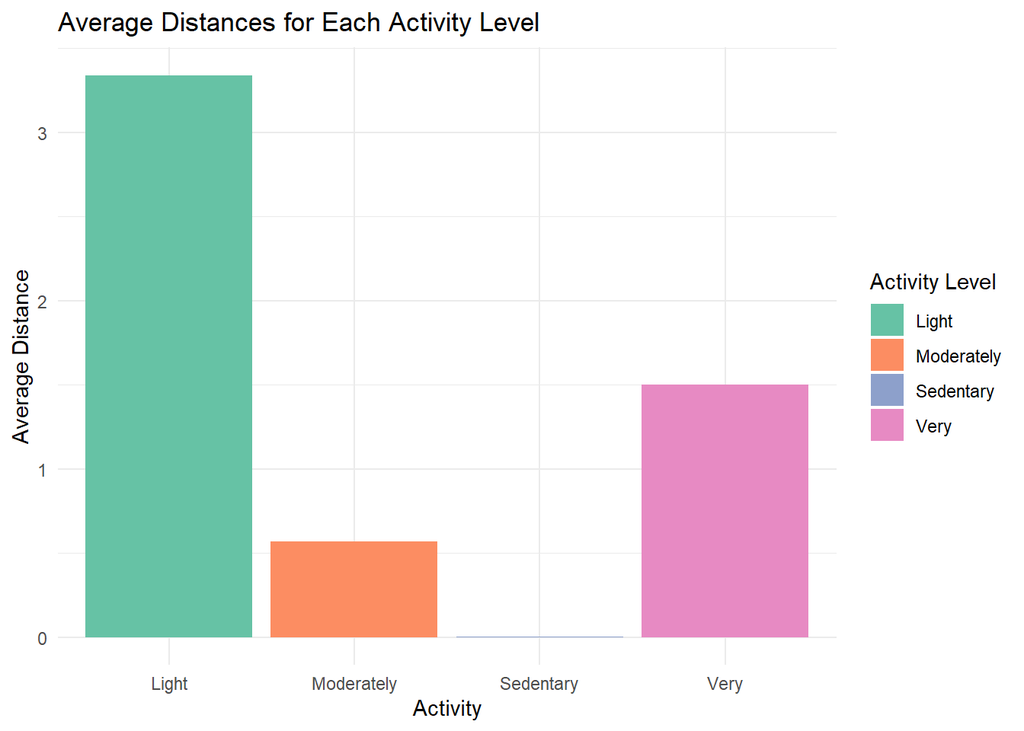

```r
activities <- activity %>%
    select('ActivityDate', 'VeryActiveDistance', 'ModeratelyActiveDistance', 'LightActiveDistance', 'SedentaryActiveDistance') %>%
    summarise(
      TotalVeryActiveDistance = mean(VeryActiveDistance),
      TotalModeratelyActiveDistance = mean(ModeratelyActiveDistance),
      TotalLightActiveDistance = mean(LightActiveDistance),
      TotalSedentaryActiveDistance = mean(SedentaryActiveDistance)
    )
#per Distance
  activities <- activity %>%
    select('ActivityDate', 'VeryActiveDistance', 'ModeratelyActiveDistance', 'LightActiveDistance', 'SedentaryActiveDistance') %>%
    summarise(
      MeanVeryActiveDistance = mean(VeryActiveDistance),
      MeanModeratelyActiveDistance = mean(ModeratelyActiveDistance),
      MeanLightActiveDistance = mean(LightActiveDistance),
      MeanSedentaryActiveDistance = mean(SedentaryActiveDistance)
    )


activities_avgs <- c(activities$MeanVeryActiveDistance ,
                     activities$MeanModeratelyActiveDistance,
                     activities$MeanLightActiveDistance,
                     activities$MeanSedentaryActiveDistance)
activities_labs <- c('Very' , 'Moderately','Light','Sedentary')
activities_data <- data.frame(ActivityLevel = activities_labs, AverageDistance =activities_avgs)

# Create a bar chart
ggplot(activities_data, aes(x = ActivityLevel, y = AverageDistance, fill = ActivityLevel)) +
  geom_bar(stat = "identity") +
  labs(title = "Average Distances for Each Activity Level",
       x = "Activity",
       y = "Average Distance") +
  scale_fill_manual(values = c("#66c2a5", "#fc8d62", "#8da0cb", "#e78ac3"),  # Color options
                    name = "Activity Level") +
  theme_minimal()
```

Based on the bar chart presented above, it is evident that light activities are the most commonly practiced, followed by very activities. moderate activities also exhibit a noticeable presence, while Sedentary intense activities are comparatively less frequently practiced. Now the question is **how Calories change Over time ?**

```r
avg_cal_per_date<- activity %>%
  select('Calories', 'ActivityDate') %>%
  group_by(ActivityDate) %>%
  summarise(total_calories = mean(Calories))
avg_cal_per_date$ActivityDate <- as.Date(avg_cal_per_date$ActivityDate, format = "%m/%d/%Y")

# Order the data by date
avg_cal_per_date <- avg_cal_per_date %>%
  arrange(ActivityDate)

avg_cal_per_date
```

```
## # A tibble: 31 × 2
##    ActivityDate total_calories
##    <date>                <dbl>
##  1 2016-04-12            2391.
##  2 2016-04-13            2287.
##  3 2016-04-14            2356.
##  4 2016-04-15            2355.
##  5 2016-04-16            2393.
##  6 2016-04-17            2231.
##  7 2016-04-18            2333.
##  8 2016-04-19            2359.
##  9 2016-04-20            2395.
## 10 2016-04-21            2422.
## # ℹ 21 more rows
```

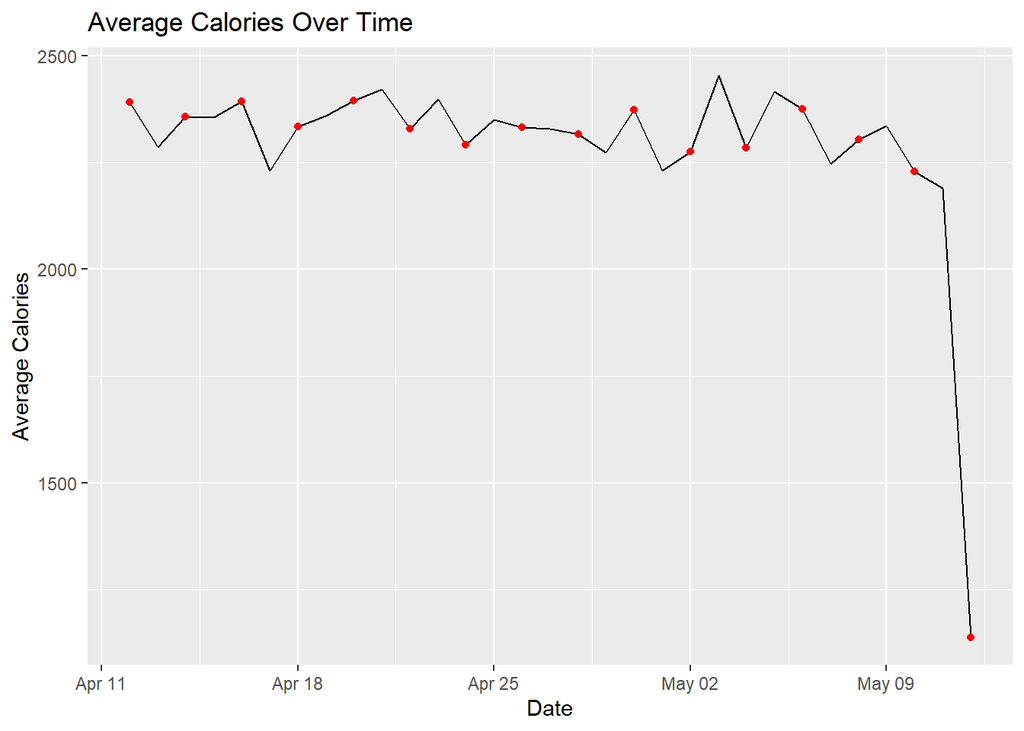

```r
ggplot(avg_cal_per_date, aes(x = ActivityDate, y = total_calories, group = 1)) +
  geom_line() +
  geom_point(data = avg_cal_per_date[seq(1, nrow(avg_cal_per_date), by = 2), ], aes(x = ActivityDate, y = total_calories), color = "red") +
  labs(title = "Average Calories Over Time", x = "Date", y = "Average Calories")
```

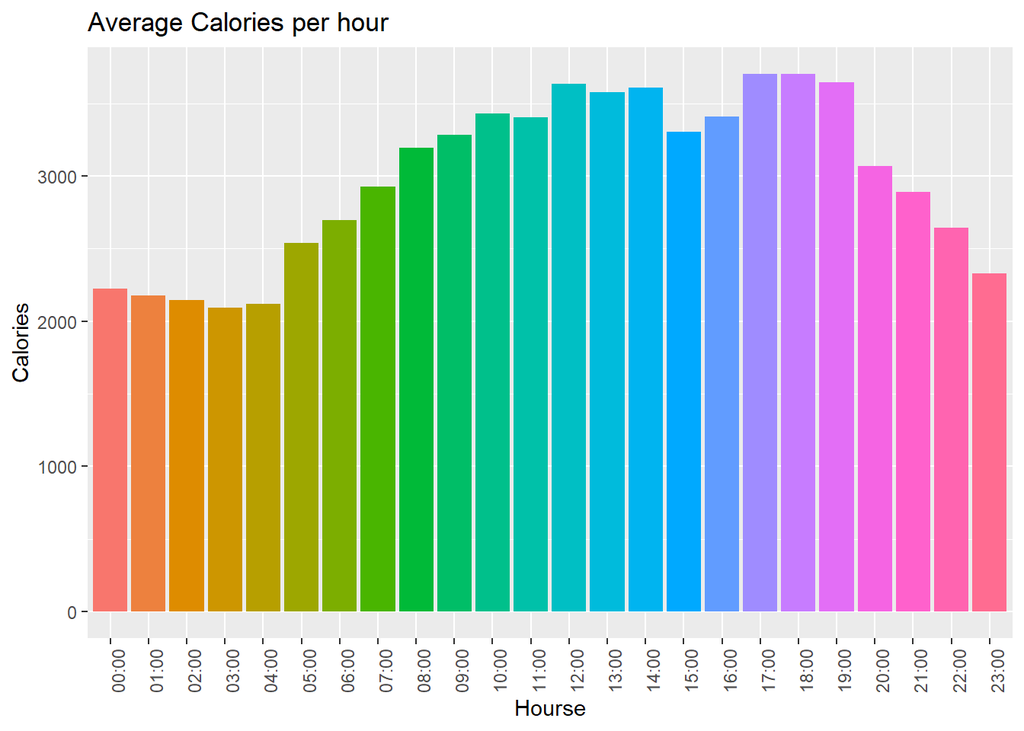

```r
##Calories Over Time

#per hour
avg_cal_per_hour<- hourly_Calories %>%
  select('ActivityHour' , 'Calories') %>%
  group_by(ActivityHour)%>%
  summarise(Mean_calories =mean(Calories))

#Format date time column
avg_cal_per_hour$ActivityHour <- as.POSIXct(avg_cal_per_hour$ActivityHour, format = "%m/%d/%Y %I:%M:%S %p")

# Add a new column with the time portion
avg_cal_per_hour$Time <- format(avg_cal_per_hour$ActivityHour, format = "%H:%M")
avg_cal_per_hour <- avg_cal_per_hour %>%
  arrange(Time)

# How Calories change Over hours Visualization
ggplot(avg_cal_per_hour, aes(x = Time, y = Mean_calories, fill = Time)) +
  geom_bar(stat = "identity") +
  labs(title = "Average Calories per hour",
       x = "Hourse",
       y = "Calories") +
  theme(axis.text.x = element_text(angle = 90, hjust = 0),legend.position = "none")
```

Here, we can pinpoint the hours when users burn more calories throughout the day, particularly during the active hours between 5:00 to 7:00 PM. By concentrating on this timeframe, we can tailor and enhance our services to better meet users’ needs during their most active periods.

The next question is: **How do users’ daily step counts vary over the course of each hour?**

```r
#Steps per hour
avg_steps_per_hour <- hourly_Steps %>%
  select('ActivityHour' ,'StepTotal') %>%
  group_by(ActivityHour)%>%
  summarise(MeanSteps = mean(StepTotal))

#Formatting Date
avg_steps_per_hour$ActivityHour <- as.POSIXct(avg_steps_per_hour$ActivityHour, format = "%m/%d/%Y %I:%M:%S %p")

# Add a new column with the time portion
avg_steps_per_hour$Time <- format(avg_steps_per_hour$ActivityHour, format = "%H:%M")

#Arrange Dataset
avg_steps_per_hour %>%
  arrange(Time)
```

```
## # A tibble: 736 × 3
##    ActivityHour        MeanSteps Time
##    <dttm>                  <dbl> <chr>
##  1 2016-04-12 00:00:00      38.5 00:00
##  2 2016-04-13 00:00:00      21.2 00:00
##  3 2016-04-14 00:00:00      37.4 00:00
##  4 2016-04-15 00:00:00      57.8 00:00
##  5 2016-04-16 00:00:00      63.3 00:00
##  6 2016-04-17 00:00:00     125.  00:00
##  7 2016-04-18 00:00:00      43.1 00:00
##  8 2016-04-19 00:00:00      15.2 00:00
##  9 2016-04-20 00:00:00      25.1 00:00
## 10 2016-04-21 00:00:00      12.7 00:00
## # ℹ 726 more rows
```

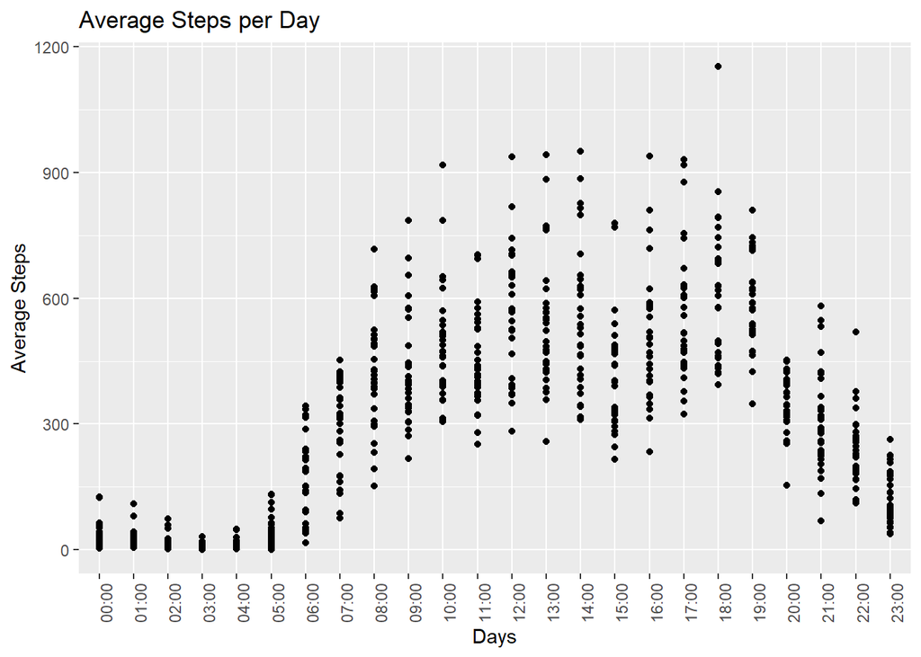

```r
#Viz

ggplot(avg_steps_per_hour, aes(x = Time, y = MeanSteps)) +
  geom_point() +
  labs(title = "Average Steps per Day",
       x = "Days",
       y = "Average Steps") +
  theme(axis.text.x = element_text(angle = 90, hjust = 0))
```

Here, we observed that users tend to take more steps during the same (5 to 7 PM) period each day. The final aspect we’ll analyze is the users’ sleep patterns and the time they spend in bed.

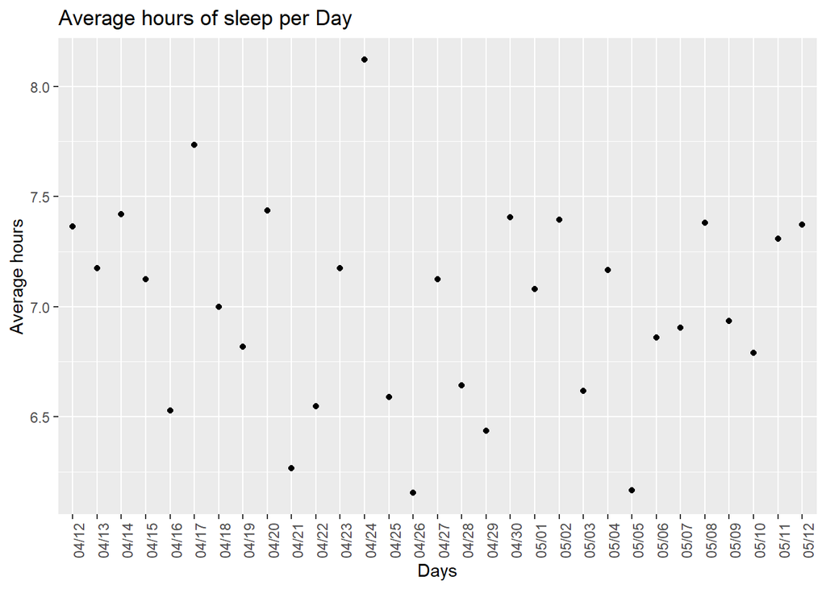

```r
## Sleep
    avg_daily_Sleep <- daily_Sleep %>%
      select('SleepDay' , 'TotalSleepRecords' , 'TotalMinutesAsleep' , 'TotalTimeInBed' ) %>%
      group_by(SleepDay) %>%
      summarise(MeanSleepRecords = mean(TotalSleepRecords),
                MeanMinutesAsleep = mean(TotalMinutesAsleep),
                MeanTimeInBed = mean(TotalTimeInBed))
    #Formatting Date
    avg_daily_Sleep$SleepDay <- as.POSIXct(avg_daily_Sleep$SleepDay, format = "%m/%d/%Y %I:%M:%S %p")
    # Add a new column with the Date portion
    avg_daily_Sleep$Day <- format(avg_daily_Sleep$SleepDay, format = "%m/%d")
    #Data arrangement
    avg_daily_Sleep <- avg_daily_Sleep %>%
      arrange(Day)
    #Viz
    ggplot(avg_daily_Sleep, aes(x = Day, y = MeanMinutesAsleep/60)) +
      geom_point() +
      labs(title = "Average hours of sleep per Day",
           x = "Days",
           y = "Average hours") +
      theme(axis.text.x = element_text(angle = 90, hjust = 0))
```

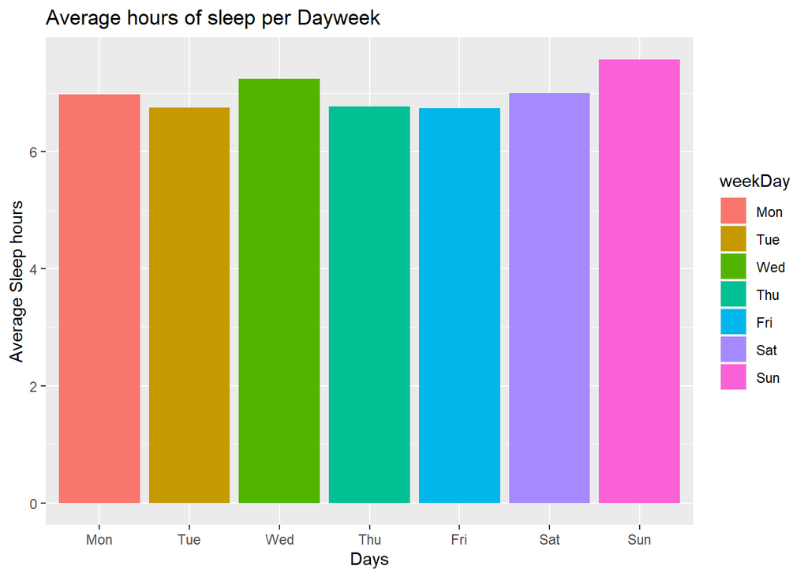

```r
    #Sleep in days of the week

    avg_daily_Sleep$weekDay <- format(avg_daily_Sleep$SleepDay, format = "%a")
    avg_sleep_weekDay <- avg_daily_Sleep %>%
      select( 'MeanSleepRecords' , 'MeanMinutesAsleep','MeanTimeInBed','weekDay') %>%
      group_by(weekDay) %>%
      summarise(AvgMeanSleepRecords =mean(MeanSleepRecords) ,
                AvgMeanMinutesAsleep =mean(MeanMinutesAsleep) ,
                AvgMeanTimeInBed =mean(MeanTimeInBed) )

    avg_sleep_weekDay$weekDay <- factor(avg_sleep_weekDay$weekDay, levels = c("Mon", "Tue", "Wed", "Thu", "Fri", "Sat", "Sun"))

    ggplot(avg_sleep_weekDay, aes(x = weekDay, y = AvgMeanMinutesAsleep/60 , fill = weekDay)) +
      geom_bar(stat = "identity") +
      labs(title = "Average hours of sleep per Dayweek",
           x = "Days",
           y = "Average Sleep hours")
```

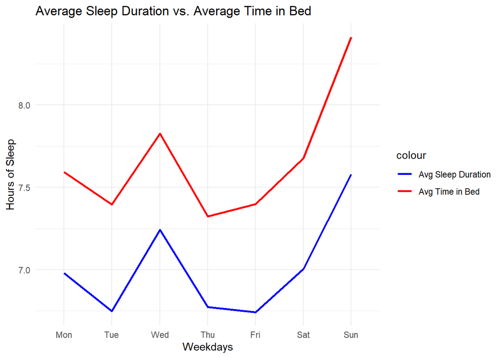

```r
    #Sleep Record vs time and Bed
    #total Sleep vs time spend in bed

    ggplot(avg_sleep_weekDay, aes(x = weekDay)) +
      geom_line(aes(y = AvgMeanMinutesAsleep/60, group = 1, color = "Avg Sleep Duration"), size = 1, linetype = "solid") +
      geom_line(aes(y = AvgMeanTimeInBed/60, group = 1, color = "Avg Time in Bed"), size = 1, linetype = "solid") +
      labs(title = "Average Sleep Duration vs. Average Time in Bed",
           x = "Weekdays",
           y = "Hours of Sleep") +
      scale_color_manual(values = c("Avg Sleep Duration" = "blue", "Avg Time in Bed" = "red"),
                         labels = c("Avg Sleep Duration", "Avg Time in Bed")) +
      theme_minimal()
```

## Act

### Business Recommendations

*It’s crucial to note that the conclusions drawn are based on the sample used in this analysis. While these insights provide valuable direction, generalizing findings to the entire user population requires consideration of a broader dataset.*

**Thank you for your continued interest and attention!**